# Preprocesamiento (Volumen II)

Detección de outliers (valores anómalos)  
(Tips de Programación)  
Santiago Banchero  
Leo Lucianna  
Juan Manuel Fernandez

Minería de Datos - UBA

### Contenidos

- Análisis gráfico de outliers
- Técnicas de detección y tratamiento de outliers
- Técnicas univariadas:
  - Detección de outliers mediante Rango intercuartil
  - Detección de outliers mediante desvíos de la media
  - Z-score
- Técnica multivariada:
  - Detección de outliers mediante Local Outlier Factor (LOF) -Multivariado-

### Limpieza de datos: Detección de Outliers

Busquemos outliers en el atributo Road_55db del dataset ruidoso:

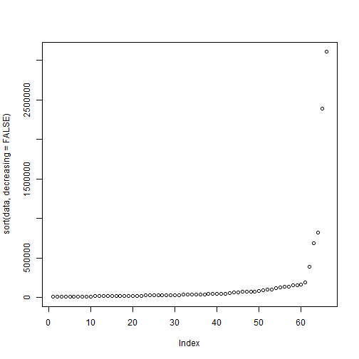

```r
ruidoso=read.csv('ruidoso.txt')
data = ruidoso$Road_55dB
plot(sort(data, decreasing = FALSE))
```

Hay outliers? Cuales?

### Análisis del atributo ruidoso$Road_55dB

Observemos analíticamente la distribución de la variable:  
Media:

```r
mean(data)
```

```
[1] 159228.8
```

Mínimo:

```r
min(data)
```

```
[1] 7600
```

Máximo:

```r
max(data)
```

```
[1] 3108200
```

### Detección de outliers: Análisis gráfico (++)

Mediante boxplot podemos observar gráficamente la distribución de la variable:

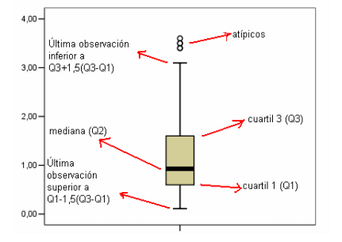

Un criterio de detección de outliers podría ser eliminar los datos que se encuentran por fuera (abajo/arriba) de los “bigotes”.

### Análisis del atributo ruidoso$Road_55dB (++)

Observemos gráficamente la distribución de la variable mediante boxplot:

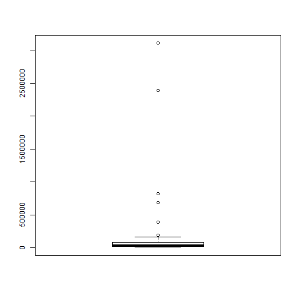

```r
boxplot(data)
```

Claramente, la distribución de la variable no es “normal”, o si? Muchas veces los outliers “esconden” la distribución real de un feature.

### Detección de Outliers mediante IRQ

- Detección de outliers mediante el IRQ*1,5 (Rango intercuartil)

```r
data.riq<-IQR(data)
print(data.riq)
```

```
[1] 59950
```

```r
cuantiles<-quantile(data, c(0.25, 0.5, 0.75), type = 7)
print(cuantiles)
```

```
  25%   50%   75%
18950 37550 78900
```

### Detección de Outliers mediante IRQ (++)

```r
outliers_min<-as.numeric(cuantiles[1])-1.5*data.riq
print(outliers_min)
```

```
[1] -70975
```

```r
outliers_max<-as.numeric(cuantiles[3])+1.5*data.riq
print(outliers_max)
```

```
[1] 168825
```

### Ruidoso$Road_55dB "sin" outliers

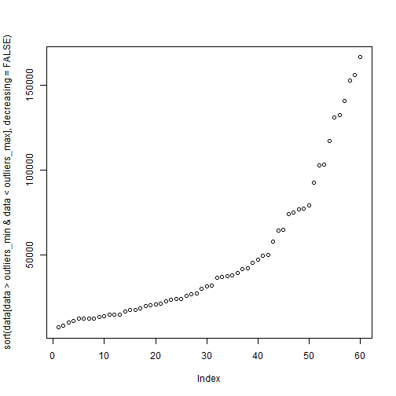

```r
plot(sort(data[data>outliers_min & data<outliers_max], decreasing = FALSE))
```

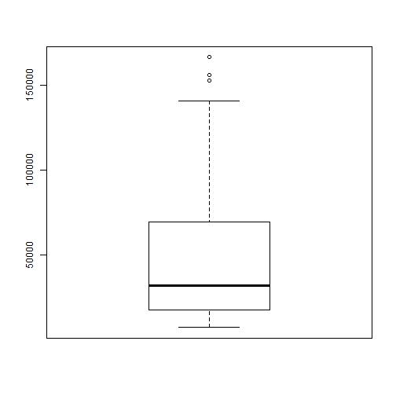

```r
boxplot(sort(data[data>outliers_min & data<outliers_max], decreasing = FALSE))
```

### Detección de Outliers mediante Desvíos de la Media

Otra alternativa es realizar detección de outliers utilizando alguna medida de tendencia central.  
Detección por N desvíos de la media (En el ejemplo N=3):

```r
N=3
data<-ruidoso$Road_55dB
desvio<-sd(data)
print(desvio)
```

```
[1] 484751.3
```

```r
outliers_max<-mean(data)+N*desvio
print(outliers_max)
```

```
[1] 1613483
```

```r
outliers_min<-mean(data)-N*desvio
print(outliers_min)
```

```
[1] -1295025
```

### Ruidoso$Road_55dB "sin" outliers

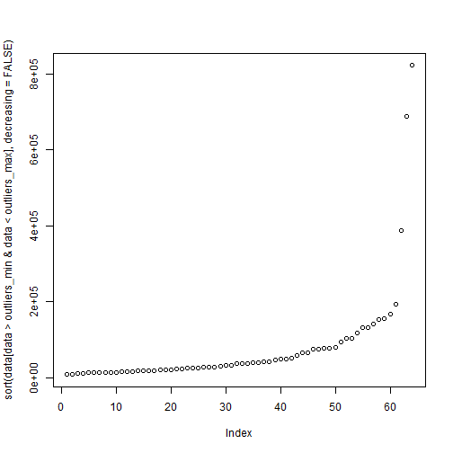

```r
plot(sort(data[data>outliers_min & data<outliers_max], decreasing = FALSE))
```

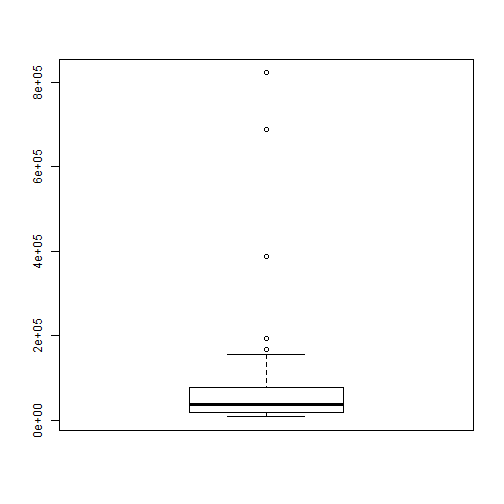

```r
boxplot(sort(data[data>outliers_min & data<outliers_max], decreasing = FALSE))
```

### Detección de Outliers mediante Z-Score

Otra variante es trabajar a través de la métrica de z-score:  
Cálculo de Z-Score:

```r
data<-ruidoso
data$zscore<-(data$Road_55dB-mean(data$Road_55dB))/sd(data$Road_55dB)
umbral<-2
```

```r
max(data$zscore)
```

```
[1] 6.083473
```

```r
min(data$zscore)
```

```
[1] -0.3127971
```

### Ruidoso$Road_55dB "sin" outliers

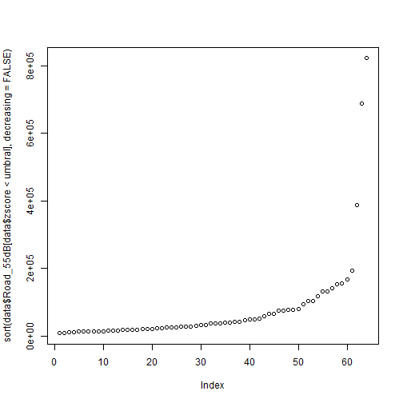

```r
plot(sort(data$Road_55dB[data$zscore<umbral], decreasing = FALSE))
```

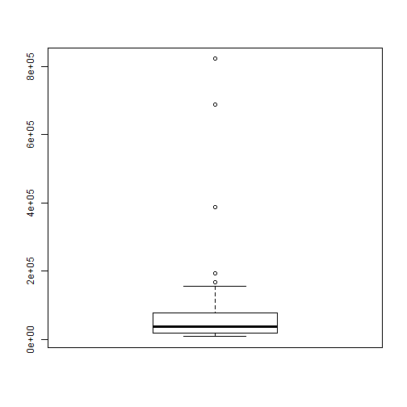

```r
boxplot(sort(data$Road_55dB[data$zscore<umbral], decreasing = FALSE))
```

### Detección de Outliers: Técnicas multivariadas

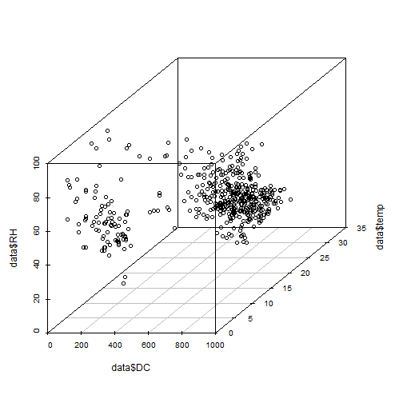

```r
library(scatterplot3d)
library(readr)
data <- read_csv("forestfires.csv")
data <- data[,c(7,9,10)]
scatterplot3d(data$DC, data$temp, data$RH)
```

### Local Outlier Factor

Ahora abordamos, Local Outlier Factor [1] que es una técnica multivariada, dado que tiene en cuenta varios atributos para la detección del outlier. La idea es calcular un score para cada instancia, el cual representa un “índice” de densidad con respecto a los K vecinos mas cercanos.

```r
# Cargamos la librería
library(Rlof)
# Calculamos LOF para k=3 vecinos por instancia
data$score<-lof(data, k=3)
umbral<-4
data$outlier <- (data$score>umbral)
data <- na.omit(data)
```

[1] https://cran.r-project.org/web/packages/Rlof/Rlof.pdf

### Outliers: LOF (++)

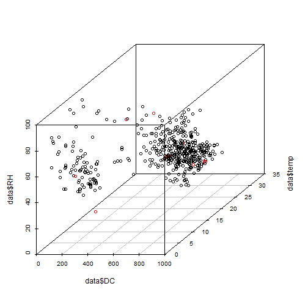

```r
data$color <- ifelse(data$outlier, "red", "black")
scatterplot3d(data$DC, data$temp, data$RH, color = data$color)
```